# Serum gamma-glutamyltranspeptidase in a Japanese health-check cohort

Dataset 9: Liver enzymes and arterial stiffness in a Japanese health-check cohort

RSR feasibility analysis

2026-08-03

# Introduction

A general health-check programme in Japan enrolled 912 men and women aged 24 to 84 years and measured a full fasting biochemistry panel alongside abdominal ultrasound and automated vascular measurements; the cohort is reported in *BMJ Open* 2014;4:e005413. Gamma-glutamyltranspeptidase (GGT) is the liver enzyme most often used as a marker of alcohol intake, but it also rises with hepatic steatosis, oxidative stress and metabolic syndrome, and raised GGT predicts cardiovascular disease and diabetes independently of drinking. Understanding what a raised GGT at a routine health check actually reflects is therefore a question about the interpretation of a very widely ordered test.

**Aim.** Among these health-check attendees, we examined which of age, sex, body mass index, systolic blood pressure, smoking status, alcohol intake, regular exercise, fasting glucose, triglycerides, HDL cholesterol, kidney function and the two other liver enzymes (ALT and AST) are independently associated with serum GGT, mutually adjusting for the others.

This is a *Purpose 3* analysis: several predictors are of interest and the question is which remain associated with the outcome after mutual adjustment.

# Methods

**Data source.** A cross-sectional Japanese health-check cohort of 912 adults attending a voluntary medical check-up programme that included a fasting blood panel, abdominal ultrasound and automated measurement of pulse-wave velocity and the ankle-brachial index.

**Variables.** The outcome is `log2_ggt`, serum gamma-GT on a base-2 logarithmic scale. The raw enzyme is severely right-skewed (skewness 5.07, median 19 U/L, maximum 274 U/L); on the log2 scale the skewness falls to 1.05, which is why the catalogue ships the transformed version and why we model it. A coefficient of *b* on this scale means that a one-unit increase in the predictor multiplies GGT by 2^*b*. Predictors are age (years), sex (reference Male, the larger group at 592 of 912), BMI (kg/m2), systolic blood pressure (mmHg), smoking status (three levels, reference Never, the largest group at 461), alcohol intake (g/week), regular exercise (reference No, the unexposed and larger group), fasting glucose (mg/dL), triglycerides (mg/dL), HDL cholesterol (mg/dL), estimated glomerular filtration rate (mL/min/1.73m2), ALT (U/L) and AST (U/L).

**`ggt` is excluded from the predictor set as a matter of arithmetic, not judgement.** `log2_ggt` is exactly `log2(ggt)` in this file - the largest absolute discrepancy across all 912 rows is 8.9e-16, i.e. floating-point noise - so regressing the outcome on `ggt` is regressing a variable on a monotone transformation of itself. Any model containing it is circular and its R-squared is meaningless.

**The predictor set was cut from the 17 remaining suggested predictors to 13.** With 883 complete cases and 14 parameters this model already has about 63 observations per parameter, so the 10-15 observations-per-parameter budget would have tolerated all 17; the cut is about **redundancy** and **interpretability** instead. Systolic and diastolic pressure correlate at r = 0.90 and carry VIFs of 5.4 and 5.7 when both are included, so only systolic pressure is kept. The four lipid measures satisfy the Friedewald identity total = LDL + HDL + triglycerides/5 to within rounding (regressing total cholesterol on the other three gives R-squared 0.955 with coefficients 1.00, 1.06 and 0.17), and with all four in the model the VIFs reach 23.9 and 19.7; only HDL cholesterol and triglycerides, the two metabolic-syndrome components, are kept. Uric acid is dropped because it duplicates information already carried by adiposity and kidney function (r = -0.30 with eGFR, r = 0.38 with BMI).

**ALT and AST are deliberately retained, despite correlating at r = 0.78.** With GGT as the outcome the other two enzymes stop being nuisance duplicates and become the substantive question: does GGT carry information about the liver beyond what ALT and AST already say? Their VIFs are reported explicitly in the diagnostics, and the interpretation of each is conditional on the other.

**Statistical analysis.** `lm()`, justified because the outcome is a continuous (log-transformed) measurement. We fitted a univariable model for each predictor first, then a single multivariable model containing all of them. Predictors were chosen in advance on subject-matter grounds, not by significance. Significance threshold 0.05; estimates are reported with 95% confidence intervals. Assumptions were checked with `performance::check_model()`, `check_heteroscedasticity()` and `check_collinearity()`, and because non-constant variance was flagged we additionally report HC3 heteroscedasticity-consistent standard errors. Analysis used R version 4.6.0 (2026-04-24) with tidyverse, gtsummary and performance.

**Missing data.** Complete-case analysis: 883 of 912 rows were analysed (29 dropped). The outcome is complete; the entire loss comes from `regular_exercise` (16 missing) and `alcohol_g_per_week` (13 missing), which do not overlap. Only 844 of 912 rows are complete on *every* column in the file.

# Results

## Sample characteristics

**Table 1. Sample characteristics.**

| **Characteristic** | **N** | **N = 883**<sup>1</sup> |
| --- | --- | --- |
| Gamma-GT (log2 U/L) | 883 | 4.25 (3.81, 4.81) |
| Age (years) | 883 | 52 (44, 58) |
| Sex | 883 |  |
| Male |  | 576 (65%) |
| Female |  | 307 (35%) |
| BMI (kg/m2) | 883 | 22.83 (20.98, 24.86) |
| Systolic BP (mmHg) | 883 | 120 (110, 130) |
| Smoking status | 883 |  |
| Never |  | 445 (50%) |
| Former |  | 247 (28%) |
| Current |  | 191 (22%) |
| Alcohol (g/week) | 883 | 4 (0, 105) |
| Takes regular exercise | 883 | 177 (20%) |
| Fasting glucose (mg/dL) | 883 | 96 (91, 102) |
| Triglycerides (mg/dL) | 883 | 81 (53, 123) |
| HDL cholesterol (mg/dL) | 883 | 52 (43, 62) |
| eGFR (mL/min/1.73m2) | 883 | 69 (62, 78) |
| ALT (U/L) | 883 | 19 (14, 26) |
| AST (U/L) | 883 | 19 (16, 23) |

<sup>1</sup> Median (Q1, Q3); n (%)

Median log2 GGT is 4.25, i.e. 19 U/L on the raw scale, with an interquartile range spanning 14 to 28 U/L - a factor of about 2.0 between the quartiles, which is why a log scale is needed. The cohort is 65% male, median age 52 years, and reported alcohol intake has a median of only 4.2 g/week but an upper quartile of 104 g/week: half the cohort barely drinks and a quarter drinks heavily.

## Exploratory figure

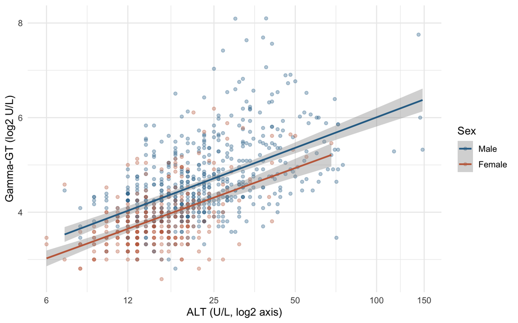

Figure 1. Log2 gamma-GT against ALT, by sex, with linear smooths.

GGT rises steadily with ALT in both sexes and the two slopes are close to parallel, but the male line sits roughly half a log2 unit above the female line across the whole range - at any given ALT, men have around 1.5 times the GGT of women.

## Univariable models

| **Characteristic** | **N** | **Beta** | **95% CI** | **p-value** |
| --- | --- | --- | --- | --- |
| Age (years) | 883 | 0.00 | 0.00, 0.01 | 0.2 |
| Sex | 883 |  |  |  |
| Male |  | — | — |  |
| Female |  | -0.73 | -0.83, -0.62 | <0.001 |
| BMI (kg/m2) | 883 | 0.08 | 0.06, 0.09 | <0.001 |
| Systolic BP (mmHg) | 883 | 0.02 | 0.01, 0.02 | <0.001 |
| Smoking status | 883 |  |  |  |
| Never |  | — | — |  |
| Former |  | 0.36 | 0.23, 0.49 | <0.001 |
| Current |  | 0.36 | 0.22, 0.50 | <0.001 |
| Alcohol (g/week) | 883 | 0.00 | 0.00, 0.00 | <0.001 |
| Takes regular exercise | 883 |  |  |  |
| No |  | — | — |  |
| Yes |  | -0.22 | -0.36, -0.08 | 0.002 |
| Fasting glucose (mg/dL) | 883 | 0.01 | 0.01, 0.02 | <0.001 |
| Triglycerides (mg/dL) | 883 | 0.00 | 0.00, 0.01 | <0.001 |
| HDL cholesterol (mg/dL) | 883 | -0.01 | -0.02, -0.01 | <0.001 |
| eGFR (mL/min/1.73m2) | 883 | -0.01 | -0.01, 0.00 | <0.001 |
| ALT (U/L) | 883 | 0.03 | 0.03, 0.04 | <0.001 |
| AST (U/L) | 883 | 0.05 | 0.04, 0.05 | <0.001 |

Abbreviation: CI = Confidence Interval

Almost everything is associated with GGT crudely. The two other liver enzymes are the strongest: each additional U/L of AST is associated with 0.0471 log2 units (95% CI 0.0409 to 0.0533) (p <0.001), i.e. GGT multiplied by 1.386 per 10 U/L, and each additional U/L of ALT with 0.0318 log2 units (95% CI 0.0285 to 0.0352) (p <0.001), a factor of 1.247 per 10 U/L. Women have -0.727 log2 units (95% CI -0.835 to -0.620) lower log2 GGT than men (p <0.001), i.e. about 40% lower GGT. Alcohol is associated with 0.0021 log2 units (95% CI 0.0017 to 0.0025) per g/week (p <0.001), a factor of 1.159 per 100 g/week. Triglycerides (0.0047 log2 units (95% CI 0.0041 to 0.0054) per mg/dL, p <0.001), BMI (0.077 log2 units (95% CI 0.059 to 0.094) per kg/m2, p <0.001), systolic pressure (0.0163 log2 units (95% CI 0.0127 to 0.0199) per mmHg, p <0.001) and fasting glucose (0.0138 log2 units (95% CI 0.0099 to 0.0176) per mg/dL, p <0.001) are all positively associated; HDL cholesterol (-0.0114 log2 units (95% CI -0.0152 to -0.0076) per mg/dL, p <0.001), eGFR (-0.0088 log2 units (95% CI -0.0135 to -0.0042) per unit, p <0.001) and regular exercise (-0.217 log2 units (95% CI -0.357 to -0.078), p = 0.002) negatively. Both former (0.356 log2 units (95% CI 0.227 to 0.486), p <0.001) and current smoking (0.361 log2 units (95% CI 0.220 to 0.502), p <0.001) are associated with GGT roughly 28% higher than never smoking. The single exception is age, which shows no crude association at all (0.0041 log2 units (95% CI -0.0019 to 0.0100), p = 0.177).

## Why adjustment is needed

**Sex** is the pivotal confounder for this outcome, and it confounds almost every other association in the list. Men have median GGT 21 U/L against 14 U/L in women, and men also drink far more (median 36 versus 0 g/week), smoke far more (69% ever-smokers against 13%), carry more weight and have higher blood pressure. Any crude behavioural or metabolic association with GGT is therefore partly a sex association.

**ALT** is the second variable that must be handled explicitly, and it works on the BMI association. Adiposity raises GGT largely by causing hepatic steatosis, and steatosis raises ALT too (BMI-ALT r = 0.43), so much of the crude BMI-GGT association is really a shared-liver-injury association. This is confounding and mediation at the same time: fat in the liver is a common cause of both enzymes rising, but it is also the pathway by which body mass acts. **Alcohol** is the third: it raises GGT directly, it is strongly patterned by sex, and drinkers here are also smokers (median alcohol 44 g/week in current smokers against 1 in never smokers), so a crude smoking coefficient is partly a drinking coefficient. Mutual adjustment lets each estimate be read as a comparison between attendees alike on the other measured characteristics.

## Multivariable model

| **Characteristic** | **Beta** | **95% CI** | **p-value** |
| --- | --- | --- | --- |
| Age (years) | 0.01 | 0.00, 0.01 | <0.001 |
| Sex |  |  |  |
| Male | — | — |  |
| Female | -0.35 | -0.47, -0.23 | <0.001 |
| BMI (kg/m2) | -0.01 | -0.02, 0.01 | 0.5 |
| Systolic BP (mmHg) | 0.00 | 0.00, 0.01 | 0.007 |
| Smoking status |  |  |  |
| Never | — | — |  |
| Former | -0.04 | -0.15, 0.07 | 0.5 |
| Current | -0.05 | -0.17, 0.07 | 0.4 |
| Alcohol (g/week) | 0.00 | 0.00, 0.00 | <0.001 |
| Takes regular exercise |  |  |  |
| No | — | — |  |
| Yes | -0.14 | -0.24, -0.03 | 0.011 |
| Fasting glucose (mg/dL) | 0.00 | 0.00, 0.01 | 0.2 |
| Triglycerides (mg/dL) | 0.00 | 0.00, 0.00 | <0.001 |
| HDL cholesterol (mg/dL) | 0.00 | 0.00, 0.01 | 0.069 |
| eGFR (mL/min/1.73m2) | 0.00 | 0.00, 0.00 | >0.9 |
| ALT (U/L) | 0.02 | 0.02, 0.03 | <0.001 |
| AST (U/L) | 0.01 | 0.00, 0.02 | 0.044 |

Abbreviation: CI = Confidence Interval

**Model fit: multivariable linear model for log2 gamma-GT**

| Statistic | Value |
| --- | --- |
| Complete-case N | 883 |
| Parameters (excl. intercept) | 14 |
| Observations per parameter | 63.1 |
| R-squared | 0.477 |
| Adjusted R-squared | 0.469 |
| Residual SE (log2 units) | 0.620 |
| SD of outcome (log2 units) | 0.850 |

The model explains 47.7% of the variance in log2 GGT (adjusted R-squared 0.469). Residual SE is 0.620 log2 units against an outcome SD of 0.850: in raw terms the model still leaves a typical error of a factor of 1.54 in either direction, which is a useful reminder of how variable this enzyme is.

Among attendees of the same sex, body mass, blood pressure, smoking, drinking, exercise, glucose, lipids, kidney function and other liver enzymes, each additional U/L of ALT is associated with 0.0208 log2 units (95% CI 0.0154 to 0.0262) (p <0.001), i.e. GGT multiplied by 1.155 per 10 U/L, and each additional U/L of AST with 0.0088 log2 units (95% CI 0.0002 to 0.0174) (p = 0.044), a factor of 1.063 per 10 U/L. Among attendees alike on everything else, each additional gram of weekly alcohol is associated with 0.0014 log2 units (95% CI 0.0010 to 0.0017) (p <0.001), a factor of 1.098 per 100 g/week, and women still have -0.352 log2 units (95% CI -0.470 to -0.235) lower log2 GGT than men (p <0.001), about 22% lower. Triglycerides remain associated (0.0023 log2 units (95% CI 0.0017 to 0.0029) per mg/dL, p <0.001), as do age (0.0087 log2 units (95% CI 0.0036 to 0.0138) per year, p <0.001), systolic pressure (0.0042 log2 units (95% CI 0.0011 to 0.0074) per mmHg, p = 0.007) and regular exercise, which is associated with -0.137 log2 units (95% CI -0.242 to -0.032) (p = 0.011), i.e. GGT about 9% lower.

Four predictors are *not* independently associated: BMI (-0.005 log2 units (95% CI -0.021 to 0.011), p = 0.534), fasting glucose (0.0023 log2 units (95% CI -0.0009 to 0.0054), p = 0.159), eGFR (0.0002 log2 units (95% CI -0.0037 to 0.0041), p = 0.927) and both smoking contrasts (-0.042 log2 units (95% CI -0.154 to 0.070) and -0.053 log2 units (95% CI -0.175 to 0.068)). HDL cholesterol is borderline and has changed direction (0.0032 log2 units (95% CI -0.0003 to 0.0067), p = 0.069). These are associations among the attendees observed, not effects of intervening.

## Unadjusted versus adjusted

**Table 2. Unadjusted and adjusted estimates.**

| **Characteristic** | **Unadjusted** **N** | **Unadjusted** **Beta** | **Unadjusted** **95% CI** | **Unadjusted** **p-value** | **Adjusted** **Beta** | **Adjusted** **95% CI** | **Adjusted** **p-value** |
| --- | --- | --- | --- | --- | --- | --- | --- |
| Age (years) | 883 | 0.00 | 0.00, 0.01 | 0.2 | 0.01 | 0.00, 0.01 | <0.001 |
| Sex | 883 |  |  |  |  |  |  |
| Male |  | — | — |  | — | — |  |
| Female |  | -0.73 | -0.83, -0.62 | <0.001 | -0.35 | -0.47, -0.23 | <0.001 |
| BMI (kg/m2) | 883 | 0.08 | 0.06, 0.09 | <0.001 | -0.01 | -0.02, 0.01 | 0.5 |
| Systolic BP (mmHg) | 883 | 0.02 | 0.01, 0.02 | <0.001 | 0.00 | 0.00, 0.01 | 0.007 |
| Smoking status | 883 |  |  |  |  |  |  |
| Never |  | — | — |  | — | — |  |
| Former |  | 0.36 | 0.23, 0.49 | <0.001 | -0.04 | -0.15, 0.07 | 0.5 |
| Current |  | 0.36 | 0.22, 0.50 | <0.001 | -0.05 | -0.17, 0.07 | 0.4 |
| Alcohol (g/week) | 883 | 0.00 | 0.00, 0.00 | <0.001 | 0.00 | 0.00, 0.00 | <0.001 |
| Takes regular exercise | 883 |  |  |  |  |  |  |
| No |  | — | — |  | — | — |  |
| Yes |  | -0.22 | -0.36, -0.08 | 0.002 | -0.14 | -0.24, -0.03 | 0.011 |
| Fasting glucose (mg/dL) | 883 | 0.01 | 0.01, 0.02 | <0.001 | 0.00 | 0.00, 0.01 | 0.2 |
| Triglycerides (mg/dL) | 883 | 0.00 | 0.00, 0.01 | <0.001 | 0.00 | 0.00, 0.00 | <0.001 |
| HDL cholesterol (mg/dL) | 883 | -0.01 | -0.02, -0.01 | <0.001 | 0.00 | 0.00, 0.01 | 0.069 |
| eGFR (mL/min/1.73m2) | 883 | -0.01 | -0.01, 0.00 | <0.001 | 0.00 | 0.00, 0.00 | >0.9 |
| ALT (U/L) | 883 | 0.03 | 0.03, 0.04 | <0.001 | 0.02 | 0.02, 0.03 | <0.001 |
| AST (U/L) | 883 | 0.05 | 0.04, 0.05 | <0.001 | 0.01 | 0.00, 0.02 | 0.044 |

Abbreviation: CI = Confidence Interval

**BMI is fully explained away.** It falls from 0.077 log2 units (95% CI 0.059 to 0.094) crude (p <0.001) to -0.005 log2 units (95% CI -0.021 to 0.011) adjusted (p = 0.534) - a coefficient that started clearly positive ends at essentially zero, and slightly negative. ALT does most of that on its own: adding ALT alone to the crude BMI model moves the coefficient from 0.0768 to 0.0185. The reading is that body mass raises GGT *through* liver fat, and once liver fat is proxied by ALT there is nothing left for BMI to explain - which makes ALT a mediator here rather than a confounder, and the adjusted BMI coefficient correspondingly hard to interpret causally.

**Smoking reverses sign and loses significance entirely.** Current smoking goes from 0.361 log2 units (95% CI 0.220 to 0.502) (p <0.001) to -0.053 log2 units (95% CI -0.175 to 0.068) (p = 0.389), and former smoking likewise. Sex alone accounts for it: adding sex to the crude smoking model moves the current-smoking coefficient from 0.361 to -0.022. Smokers here are 92% male, and men have much higher GGT, so the crude smoking association was a sex association.

**HDL cholesterol changes direction.** Crudely it is -0.0114 log2 units (95% CI -0.0152 to -0.0076) (p <0.001) - higher HDL, lower GGT - and adjusted it is 0.0032 log2 units (95% CI -0.0003 to 0.0067) (p = 0.069), pointing the other way. Sex and triglycerides are jointly responsible: adding those two alone to the crude model already moves the coefficient to 0.0052. Because HDL is inversely correlated with triglycerides (r = -0.40) and women have both higher HDL and lower GGT, the crude negative association was carrying two other variables. The adjusted estimate is borderline and should not be over-read.

**Two barely move in relative terms.** Alcohol falls only from 0.0021 log2 units (95% CI 0.0017 to 0.0025) to 0.0014 log2 units (95% CI 0.0010 to 0.0017), retaining about 63% of its crude size and remaining highly significant, and regular exercise from -0.217 log2 units (95% CI -0.357 to -0.078) to -0.137 log2 units (95% CI -0.242 to -0.032). These two are the behavioural findings that survive everything else in the file.

## Diagnostics

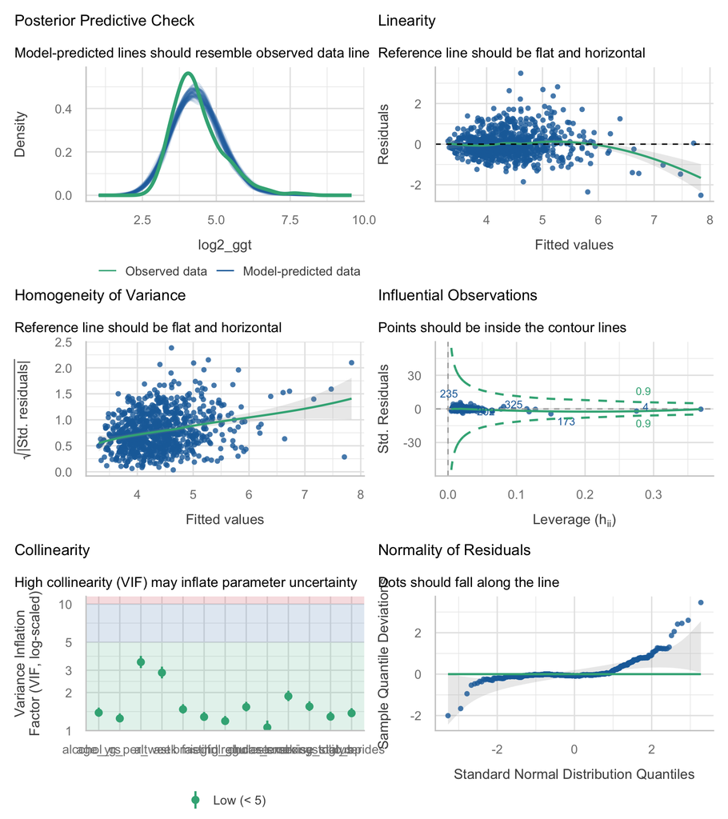

| Term | VIF | VIF_CI_low | VIF_CI_high | SE_factor | Tolerance | Tolerance_CI_low | Tolerance_CI_high |
| --- | --- | --- | --- | --- | --- | --- | --- |
| age_yrs | 1.386915 | 1.287666 | 1.520407 | 1.177673 | 0.7210248 | 0.6577188 | 0.7765991 |
| sex | 1.870473 | 1.710136 | 2.067011 | 1.367652 | 0.5346243 | 0.4837904 | 0.5847489 |
| bmi | 1.474013 | 1.363410 | 1.618276 | 1.214089 | 0.6784203 | 0.6179414 | 0.7334550 |
| systolic_bp | 1.288776 | 1.202848 | 1.411103 | 1.135243 | 0.7759300 | 0.7086653 | 0.8313601 |
| smoking_status | 1.550900 | 1.430474 | 1.705015 | 1.115953 | 0.6447870 | 0.5865053 | 0.6990689 |
| alcohol_g_per_week | 1.248366 | 1.168222 | 1.366693 | 1.117303 | 0.8010472 | 0.7316935 | 0.8560019 |
| regular_exercise | 1.060613 | 1.018330 | 1.200431 | 1.029861 | 0.9428508 | 0.8330340 | 0.9819997 |
| fasting_glucose | 1.190855 | 1.119516 | 1.304775 | 1.091263 | 0.8397331 | 0.7664156 | 0.8932433 |
| triglycerides | 1.373467 | 1.276002 | 1.505350 | 1.171950 | 0.7280846 | 0.6642972 | 0.7836981 |
| hdl_cholesterol | 1.538001 | 1.419214 | 1.690447 | 1.240162 | 0.6501947 | 0.5915595 | 0.7046156 |

[output cut: 3 more lines]

**Table 3. HC3 heteroscedasticity-consistent standard errors.**

| Term | Estimate | SE (OLS) | SE (HC3) | 95% CI (HC3) | p (HC3) |
| --- | --- | --- | --- | --- | --- |
| age_yrs | 0.0087 | 0.0026 | 0.0024 | 0.004 to 0.013 | 0.000 |
| sexFemale | -0.3524 | 0.0599 | 0.0640 | -0.478 to -0.227 | 0.000 |
| bmi | -0.0051 | 0.0081 | 0.0087 | -0.022 to 0.012 | 0.563 |
| systolic_bp | 0.0042 | 0.0016 | 0.0016 | 0.001 to 0.007 | 0.009 |
| smoking_statusFormer | -0.0416 | 0.0570 | 0.0598 | -0.159 to 0.076 | 0.486 |
| smoking_statusCurrent | -0.0534 | 0.0619 | 0.0688 | -0.188 to 0.082 | 0.438 |
| alcohol_g_per_week | 0.0014 | 0.0002 | 0.0002 | 0.001 to 0.002 | 0.000 |
| regular_exerciseYes | -0.1371 | 0.0536 | 0.0560 | -0.247 to -0.027 | 0.015 |
| fasting_glucose | 0.0023 | 0.0016 | 0.0013 | -0.000 to 0.005 | 0.072 |
| triglycerides | 0.0023 | 0.0003 | 0.0005 | 0.001 to 0.003 | 0.000 |
| hdl_cholesterol | 0.0032 | 0.0018 | 0.0019 | -0.001 to 0.007 | 0.094 |
| egfr | 0.0002 | 0.0020 | 0.0020 | -0.004 to 0.004 | 0.928 |
| alt | 0.0208 | 0.0027 | 0.0034 | 0.014 to 0.027 | 0.000 |
| ast | 0.0088 | 0.0044 | 0.0065 | -0.004 to 0.022 | 0.178 |

**Collinearity is real but tolerable, and it is concentrated exactly where expected.** The two largest VIFs are 3.48 for ALT and 2.87 for AST - the deliberately retained correlated pair - followed by 1.87 for sex. None exceeds the conventional threshold of 5, so both enzyme coefficients are estimable, but they are competing: the standard error on ALT is inflated by a factor of about 1.87 relative to an uncorrelated predictor, and this is why AST’s coefficient collapses on adjustment while ALT’s survives. Had all three enzymes been available as predictors the situation would be worse; had all four lipids been included, worse still (largest VIF 23.9 in the 17-predictor model).

**Influence.** The largest Cook’s distance is 0.228 and the largest leverage 0.369. Both are well inside the usual contours; the highest-leverage observations are the very heavy drinkers, whose reported intake reaches 952 g/week, but no single participant determines the fit.

# Discussion

In this Japanese health-check cohort, a raised gamma-GT is best explained by three things: ALT, alcohol and sex. Holding everything else constant, GGT is multiplied by 1.155 per 10 U/L of ALT, 1.098 per 100 g of weekly alcohol, and is about 22% lower in women than in men. Regular exercise is associated with GGT about 9% lower. The crude associations with BMI, fasting glucose, kidney function and smoking all disappear once these are accounted for; the BMI association in particular is fully absorbed by ALT, which is consistent with body mass acting on GGT through hepatic fat rather than through any separate route. Practically, this supports the conventional reading of a raised GGT at a health check - ask about alcohol and look at the rest of the liver panel - and argues against treating it as an independent metabolic marker once ALT is known.

**Limitations.** The design is cross-sectional and the “predictors” here include two other enzymes measured from the same blood draw, so nothing in the ALT and AST coefficients can be read causally at all: they are contemporaneous markers of the same organ, not exposures. Adjusting for ALT is adjusting for a mediator of the BMI-GGT relationship, so the null BMI coefficient is an over-adjusted estimate and should not be reported as “BMI does not affect GGT”. Alcohol is self-reported in g/week, with 285 attendees reporting exactly zero and under-reporting concentrated among heavy drinkers, which will bias the alcohol coefficient toward the null - the true alcohol-GGT gradient is almost certainly steeper than the one estimated here. Health-check attendees are self-selected and healthier than the general Japanese population, and people with known liver disease may avoid or be excluded from such programmes, further compressing the range of the outcome. Hepatitis B and C serology, medication use (statins, anticonvulsants and several other drug classes induce GGT) and body-composition measures beyond BMI are all absent. Residual variance is non-constant and residuals are non-normal even after the log2 transformation; HC3 standard errors address inference but not fit. 29 of 912 rows were dropped for missing exercise or alcohol. All estimates are associations, not causal effects.

**Future work.** Repeat with a validated alcohol questionnaire and hepatitis serology, and model GGT jointly with ALT and AST as correlated markers of a single latent liver process rather than treating two of them as covariates for the third.

# Feasibility notes

*NOT part of a student report.*

- **Verdict: USABLE.** `log2_ggt` is complete (0 missing), well behaved on the log2 scale, and produces a model with R-squared 0.48 and several clearly significant, substantively sensible coefficients. It is the most interpretable of the three linear outcomes in this dataset.
- **FATAL if `ggt` is used as a predictor.** `log2_ggt` is exactly `log2(ggt)` (maximum discrepancy across all 912 rows: 8.9e-16). A model containing `ggt` is regressing the outcome on a monotone transformation of itself and returns an R-squared of about 0.741 from that one term alone. `ggt` is not in the catalogue’s suggested predictor list, but it is in the shipped file and it is the obvious thing for a careless student to grab. Worth an explicit caution.
- **MAJOR: `log2_ggt` must be removed from the suggested predictor list when it is the outcome.** `meta.json` currently lists `log2_ggt` both as an outcome and as a suggested predictor. A student copying the predictor vector verbatim will fit `log2_ggt ~ ... + log2_ggt`. R drops the term with the warning “the response appeared on the right-hand side and was dropped” - but the template’s setup chunk sets `warning = FALSE`, so that warning never reaches the knitted document. The model runs, the table looks fine, and it is not the model the student described in their Methods.
- **MAJOR: ALT and AST are the interesting-but-collinear pair** (r = 0.78; VIFs 3.48 and 2.87). Both stay under 5, so no automated check will complain, but AST’s coefficient drops from 0.0471 log2 units (95% CI 0.0409 to 0.0533) crude to 0.0088 log2 units (95% CI 0.0002 to 0.0174) adjusted, i.e. to about 19% of its crude value, purely because ALT is in the model. Students will report “AST is only weakly associated with GGT”, which is a statement about ALT, not about AST.
- **MAJOR conceptual problem: the strongest predictors are not exposures.** ALT and AST come from the same blood sample as the outcome and index the same organ. Treating them as predictors of GGT is a prediction exercise dressed as an aetiological one, and adjusting for them turns the BMI coefficient from 0.077 log2 units (95% CI 0.059 to 0.094) into -0.005 log2 units (95% CI -0.021 to 0.011) by conditioning on a mediator. A student who omits the enzymes gets a substantively different and arguably more defensible model (BMI coefficient 0.0302, R-squared 0.347). Both are legitimate; the two lead to opposite conclusions about adiposity.
- **MAJOR: failed diagnostics even after transformation.** Heteroscedasticity p <0.001 and non-normality p <0.001. The log2 scale is a large improvement over raw GGT (skewness 5.07 to 1.05) but is not sufficient. Under HC3 standard errors **AST loses significance** (p = 0.044 under OLS to p = 0.178 under HC3); every other coefficient keeps its status. So the one borderline enzyme finding in the model is exactly the one that robust inference kills.
- **MINOR: HDL cholesterol reverses sign** on adjustment (-0.0114 log2 units (95% CI -0.0152 to -0.0076) to 0.0032 log2 units (95% CI -0.0003 to 0.0067), p = 0.069), driven by sex and triglycerides. Borderline either way; a good discussion point but an easy one to get wrong.
- **MINOR: smoking looks like a strong crude predictor and is entirely a sex effect.** Current smokers are 92% male. Adding sex alone moves the current-smoking coefficient from 0.361 to -0.022.
- **MINOR: alcohol has a very heavy right tail** (median 4.2 g/week, maximum 952, with 285 exact zeros). It is the source of the highest-leverage observations (maximum hat value 0.369), though none is influential. A student might reasonably log or categorise it; nobody will be penalised for using it raw.
- **MINOR: complete-case loss is small** - 883 of 912 (3.2%), from `regular_exercise` and `alcohol_g_per_week` only.
- No separation issues (linear model), no sparse-cell problems, and no predictor with heavy missingness.